# UFO sightings

Barna Lipics

2025-12-13

## UFO Sightings

This is an analysis on UFO sightings for Statistical analysis in R course in ELTE PPK, 2025-26 I. semester.

```r
# Read data directly from the web source
ufo_raw <- read_csv("https://raw.githubusercontent.com/rfordatascience/tidytuesday/main/data/2019/2019-06-25/ufo_sightings.csv")
# Quick look at the raw data structure
skim(ufo_raw)
```

Data summary

| Name | ufo_raw |
| --- | --- |
| Number of rows | 80332 |
| Number of columns | 11 |
| _______________________ |  |
| Column type frequency: |  |
| character | 8 |
| numeric | 3 |
| ________________________ |  |
| Group variables | None |

**Variable type: character**

| skim_variable | n_missing | complete_rate | min | max | empty | n_unique | whitespace |
| --- | --- | --- | --- | --- | --- | --- | --- |
| date_time | 0 | 1.00 | 14 | 16 | 0 | 69586 | 0 |
| city_area | 0 | 1.00 | 1 | 69 | 0 | 19900 | 0 |
| state | 5797 | 0.93 | 2 | 2 | 0 | 67 | 0 |
| country | 9670 | 0.88 | 2 | 2 | 0 | 5 | 0 |
| ufo_shape | 1932 | 0.98 | 3 | 9 | 0 | 29 | 0 |
| described_encounter_length | 0 | 1.00 | 2 | 31 | 0 | 8349 | 0 |
| description | 15 | 1.00 | 1 | 246 | 0 | 79996 | 0 |
| date_documented | 0 | 1.00 | 8 | 10 | 0 | 317 | 0 |

**Variable type: numeric**

| skim_variable | n_missing | complete_rate | mean | sd | p0 | p25 | p50 | p75 | p100 | hist |
| --- | --- | --- | --- | --- | --- | --- | --- | --- | --- | --- |
| encounter_length | 3 | 1 | 9017.23 | 620228.37 | 0.00 | 30.00 | 180.00 | 600.00 | 9.7836e+07 | ▇▁▁▁▁ |
| latitude | 1 | 1 | 38.12 | 10.47 | -82.86 | 34.13 | 39.41 | 42.79 | 7.2700e+01 | ▁▁▁▇▅ |
| longitude | 0 | 1 | -86.77 | 39.70 | -176.66 | -112.07 | -87.90 | -78.75 | 1.7844e+02 | ▃▇▁▁▁ |

## Setting the variable types and basic cleaning

- Recode unknown, other, etc. to NA
- Add continent field
- Add country field, since the data contains only 5 values, which is not right.

```r
# To add continent information
coords_lookup <- function(points, output_type = "continent") {
  results <- rep(NA, nrow(points))

  # Identify valid points
  valid_indices <- which(!is.na(points$longitude) & !is.na(points$latitude))

  # Early exit if no valid data
  if(length(valid_indices) == 0) return(results)

  # Extract valid points
  valid_points <- points[valid_indices, c("longitude", "latitude")]

  # 'low' resolution is faster
  countriesSP <- getMap(resolution='low')

  # Spatial overlay
  pointsSP = SpatialPoints(valid_points, proj4string=CRS(proj4string(countriesSP)))
  indices = over(pointsSP, countriesSP)

  # Select output based on parameter
  if(output_type == "continent") {
    # 'REGION' is the column for continents in rworldmap
    results[valid_indices] <- as.character(indices$REGION)
  } else if (output_type == "country") {
    # 'ADMIN' is the column for country names
    results[valid_indices] <- as.character(indices$ADMIN)
  } else {
    warning("Invalid output_type. Please use 'continent' or 'country'.")
  }

  return(results)
}

ufo_clean <- ufo_raw %>%
  # Parse the date_time column (mdy_hm format)
  mutate(date_time = mdy_hm(date_time)) %>%
  # Recode the unknowns to one category
  mutate(ufo_shape = ifelse(ufo_shape %in% c("unknown", "other", "NA"), NA, ufo_shape)) %>%
  # Add the continent and country field
  mutate(
      # Call 1: Get continent
      continent = coords_lookup(data.frame(longitude, latitude), output_type = "continent"),
      # Call 2: Get country Name
      country = coords_lookup(data.frame(longitude, latitude), output_type = "country")
    ) %>%
  # Extract useful time components
  mutate(
    year = year(date_time),
    hour = hour(date_time),
    # Categorize time of day
    time_of_day = case_when(
      hour >= 6 & hour < 12 ~ "Morning",
      hour >= 12 & hour < 18 ~ "Afternoon",
      hour >= 18 & hour < 24 ~ "Evening",
      TRUE ~ "Night"
    )
  ) %>%
  # Convert character columns to factors for modeling
  mutate(
    ufo_shape = as.factor(ufo_shape),
    country = as.factor(country),
    continent = as.factor(continent)
  )
```

## Let’s see some basic statistics

- Top 10 countries
- Number of observations by continent
- Numbers of observations by shape

It is interesting to see that either UFOs are showing up to English-speaking countries mostly - or the sourcing of the data is focused on that. Having the US as top alone wouldn’t be interesting, but the fact that the top 4 are English-speaking countries raises the question if that is a cultural thing to look more for UFOs.

```r
# Top 10 Countries by number of observations
top_countries <- ufo_clean %>%
  filter(!is.na(country) & country != "") %>%
  count(country, name = "Count") %>%
  arrange(desc(Count)) %>%
  head(10)

DT::datatable(
  top_countries,
  caption = "Table 1: Top 10 Countries with most UFO Sightings",
  options = list(pageLength = 10, dom = 't')
)
```

|  | country | Count |
| --- | --- | --- |
| 1 | United States of America | 68128 |
| 2 | Canada | 3524 |
| 3 | United Kingdom | 2217 |
| 4 | Australia | 610 |
| 5 | Mexico | 348 |
| 6 | India | 221 |
| 7 | Germany | 138 |
| 8 | Netherlands | 112 |
| 9 | South Africa | 91 |
| 10 | New Zealand | 88 |

```r
# Observations by continent
continent_counts <- ufo_clean %>%
  filter(!is.na(continent) & continent != "") %>%
  count(continent, name = "Count") %>%
  arrange(desc(Count))

DT::datatable(
  continent_counts,
  caption = "Table 2: UFO Sightings by Continent",
  options = list(pageLength = 10, dom = 't')
)
```

|  | continent | Count |
| --- | --- | --- |
| 1 | North America | 71652 |
| 2 | Europe | 3235 |
| 3 | Asia | 725 |
| 4 | Australia | 703 |
| 5 | South America | 681 |
| 6 | Africa | 156 |
| 7 | Antarctica | 1 |

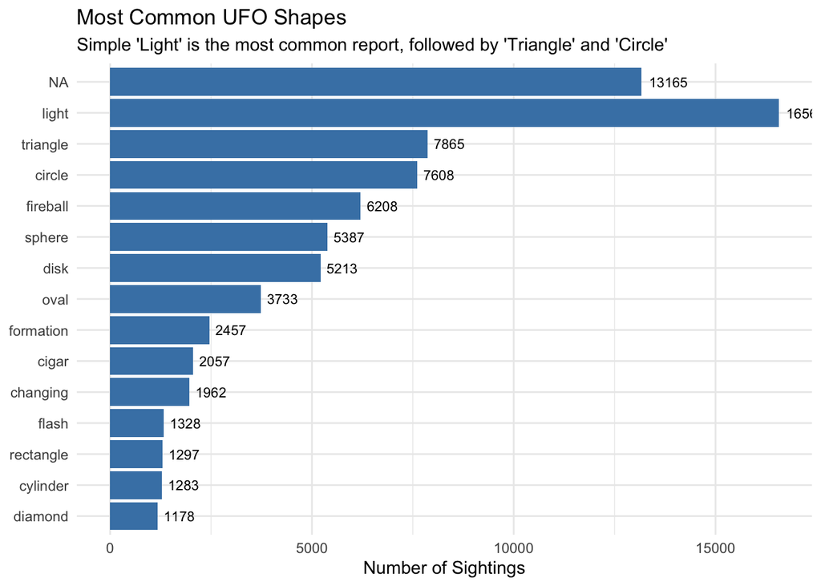

```r
ufo_clean %>%
  count(ufo_shape) %>%
  mutate(ufo_shape = fct_reorder(ufo_shape, n)) %>%
  # Filter to top 15 shapes for readability
  top_n(15, n) %>%
  ggplot(aes(x = n, y = ufo_shape)) +
  geom_col(fill = "steelblue") +
  geom_text(aes(label = n), hjust = -0.2, size = 3) +
  theme_minimal() +
  labs(
    title = "Most Common UFO Shapes",
    subtitle = "Simple 'Light' is the most common report, followed by 'Triangle' and 'Circle'",
    x = "Number of Sightings",
    y = NULL
  )
```

## Visualizing the sightings on the world map.

It seems that the sightings are heavily concentrated in the USA and Europe, but also India and Australia has some more prevalent sightings. Probably the data is not as thoroughly administered in the less developed countries, because most probably UFOs are not that picky.

Another reason could be that people in more developed countries are more exposed to news and media that raises their awareness/interest in UFOs.

Most probably the distribution of data is related to the mix of these factors.

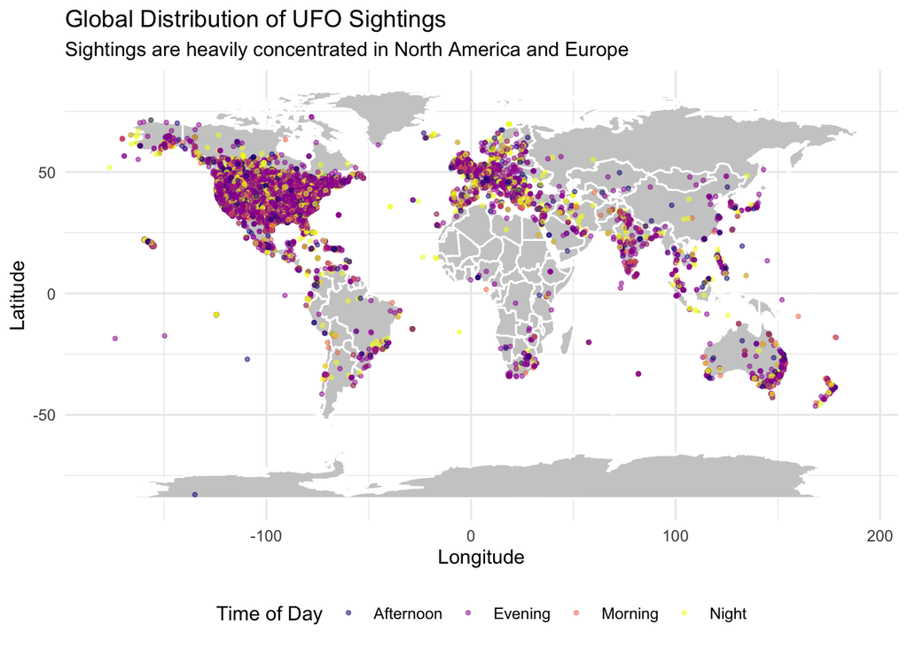

```r
# Get world map data
world_map <- map_data("world")

ggplot() +
  # Draw the world map
  geom_polygon(data = world_map, aes(x = long, y = lat, group = group),
               fill = "gray80", color = "white") +
  # Overlay UFO sightings
  geom_point(data = ufo_clean, aes(x = longitude, y = latitude, color = time_of_day),
             alpha = 0.5, size = 0.8) +
  scale_color_viridis_d(option = "plasma", name = "Time of Day") +
  theme_minimal() +
  labs(
    title = "Global Distribution of UFO Sightings",
    subtitle = "Sightings are heavily concentrated in North America and Europe",
    x = "Longitude",
    y = "Latitude"
  ) +
  theme(legend.position = "bottom")
```

## Shape preference per continent We can see an interesting attribute of data - in more developed regions like North America and Europe the triangle is more prevalent shape compared to less developed regions. A proportions test was added to check if there’s a statistical difference - it turns out there’s a statistically significant but meaninglessly small difference between Western and non-Western countries in the amount of triangle sightings.

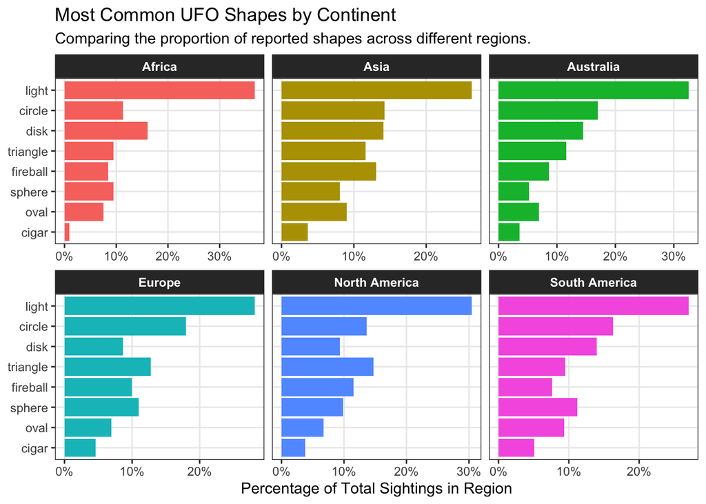

```r
# Identify continents with enough data to be meaningful
# (e.g., at least 50 sightings total)
valid_continents <- ufo_clean %>%
  filter(!is.na(continent) & continent != "") %>%
  count(continent) %>%
  filter(n > 50) %>%
  pull(continent)

shape_geography <- ufo_clean %>%
  # Filter to common shapes
  filter(ufo_shape %in% c("light", "triangle", "circle", "fireball", "sphere", "disk", "oval", "cigar")) %>%
  # Remove low-data continents and NA
  filter(continent %in% valid_continents) %>%
  count(continent, ufo_shape) %>%
  group_by(continent) %>%
  mutate(prop = n / sum(n)) %>%
  ungroup()

# Plot: Small multiples
ggplot(shape_geography, aes(x = prop, y = reorder(ufo_shape, prop))) +
  geom_col(aes(fill = continent), show.legend = FALSE) +
  facet_wrap(~continent, scales = "free_x") + # Create a separate panel for each continent
  scale_x_continuous(labels = scales::percent_format(accuracy = 1)) +
  labs(
    title = "Most Common UFO Shapes by Continent",
    subtitle = "Comparing the proportion of reported shapes across different regions.",
    x = "Percentage of Total Sightings in Region",
    y = NULL
  ) +
  theme_bw() +
  theme(
    strip.background = element_rect(fill = "gray20"),
    strip.text = element_text(color = "white", face = "bold"),
    panel.grid.minor = element_blank()
  )
```

```r
### Hypothesis Test: The "Western Triangle" Theory
# Research Question: Are Triangle sightings significantly more prevalent in Western countries?

# Define the groups
triangle_test_data <- ufo_clean %>%
  filter(!is.na(continent), !is.na(ufo_shape)) %>%
  mutate(
    # Define "Western" as North America, Europe, and Australia
    is_western = ifelse(continent %in% c("North America", "Europe"), "Western", "Non-Western"),
    # Define "Target Shape"
    is_triangle = ifelse(ufo_shape == "triangle", "Triangle", "Other")
  )

table_triangle <- table(triangle_test_data$is_western, triangle_test_data$is_triangle)

# Run a Proportions Test
prop_result <- prop.test(table_triangle)

# Display Results
datatable(tidy(prop_result))
```

|  | estimate1 | estimate2 | statistic | p.value | parameter | conf.low | conf.high | method | alternative |
| --- | --- | --- | --- | --- | --- | --- | --- | --- | --- |
| 1 | 0.912041884816754 | 0.8809874016755133 | 16.86533766846817 | 4.012773627710675e-05 | 1 | 0.01783157606974306 | 0.04427739021273835 | 2-sample test for equality of proportions with continuity correction | two.sided |

## Detail of shape vs. time

I had a theory that if people are **really** observing something, the longer they see them, the more details they’ll be able to recall. In our case, my thought is that more time they see it the more specific shape they’ll describe - so instead of **light** they’ll be able to recall a **triangle**. Based on cognitive theories, I bucketed the time of observations to these categories: 1. Psychological Present (~3s): Pöppel (1997); Wittmann (2011) 2. Working Memory Limit (~30s): Cowan (2010) 3. Retrospective Estimation (>3m): Block & Zakay (1997)

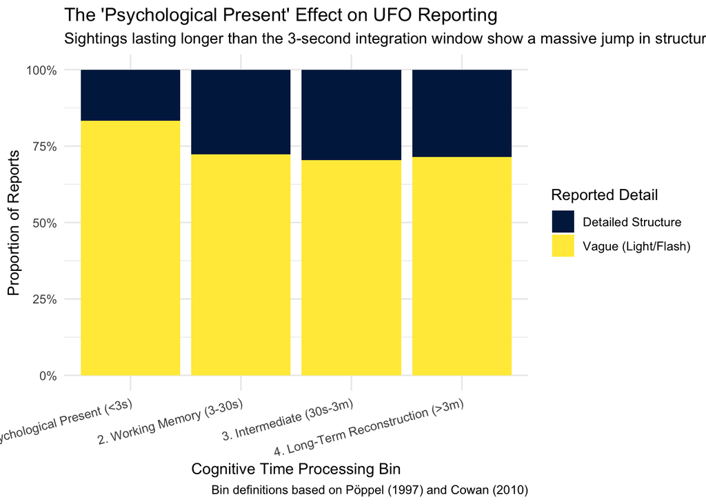

```r
ufo_cognitive <- ufo_clean %>%
  filter(!is.na(ufo_shape), !is.na(encounter_length)) %>%
  mutate(
    cognitive_bin = case_when(
      # The 3-second integration window (Pöppel, 1997)
      encounter_length <= 3 ~ "1. Psychological Present (<3s)",

      # Working memory decay limit without rehearsal (Cowan, 2010)
      encounter_length <= 30 ~ "2. Working Memory (3-30s)",

      # Attention-based "Prospective" estimation window (Block & Zakay, 1997)
      encounter_length <= 180 ~ "3. Intermediate (30s-3m)",

      # "Retrospective" reconstruction (Long-term memory retrieval)
      TRUE ~ "4. Long-Term Reconstruction (>3m)"
    ),

    # Define "High Detail" shapes vs "Low Detail" shapes
    is_detailed = ifelse(
      ufo_shape %in% c("triangle", "disk", "cigar", "formation", "diamond"),
      "Detailed Structure",
      "Vague (Light/Flash)"
    )
  )

# Visualization
ggplot(ufo_cognitive, aes(x = cognitive_bin, fill = is_detailed)) +
  geom_bar(position = "fill") +
  scale_y_continuous(labels = scales::percent) +
  scale_fill_viridis_d(option = "cividis", name = "Reported Detail") +
  theme_minimal() +
  labs(
    title = "The 'Psychological Present' Effect on UFO Reporting",
    subtitle = "Sightings lasting longer than the 3-second integration window show a massive jump in structural detail.",
    x = "Cognitive Time Processing Bin",
    y = "Proportion of Reports",
    caption = "Bin definitions based on Pöppel (1997) and Cowan (2010)"
  ) +
  theme(axis.text.x = element_text(angle = 15, hjust = 1))
```

```r
# Chi-Square
chi_sq_result <- chisq.test(table(ufo_cognitive$cognitive_bin, ufo_cognitive$is_detailed))

# Tidy the results into a dataframe
chi_sq_df <- tidy(chi_sq_result)
DT::datatable(
  chi_sq_df,
  caption = "Table: Chi-Square Test Results (Cognitive Bins vs. Detail)",
  options = list(dom = 't'),
  rownames = FALSE # Hides the row number "1"
) %>%
  DT::formatRound(columns = c("statistic", "p.value"), digits = 4)
```

| statistic | p.value | parameter | method |
| --- | --- | --- | --- |
| 266.1159194144844 | 2.136784325298099e-57 | 3 | Pearson's Chi-squared test |